# Non-standard problems in feature engineering

## December 2018

## https://github.com/pgurazada/Talks

# What are non-standard problems?

[output not shown]

### They are no canned solutions

# The problems

### Distributions and transformations

### Missing Values

### Correlations

# Problem 1

[figure not shown]

Here is a general purpose function to plot histograms.

```python
def plot_histogram(data_df, feature_label, nb_bins=10):

    plt.hist(data_df[feature_label],
             bins=nb_bins,
             color='black',
             edgecolor='white',
             linewidth=1.2)

    plt.xlabel(feature_label)
    plt.title('Distribution of ' +
              feature_label +
              ' (bins = ' + str(nb_bins) + ')')
```

```python
churn_raw_df = pd.read_excel('data/WA_Fn-UseC_-Telco-Customer-Churn.xlsx',
                             na_values=' ')

churn_data_df = churn_raw_df.drop(columns=['customerID']).dropna()

print(churn_data_df.shape)
```

```
(7032, 20)
```

Split the data into train and test

```python
churn_features = churn_data_df.drop(columns=['Churn'])
churn_labels = churn_data_df['Churn']


X_train, X_test, y_train, y_test = train_test_split(churn_features,
                                                    churn_labels,
                                                    test_size=0.2,
                                                    random_state=20130810)
```

### Now, let us plot the histogram with varying number of bins

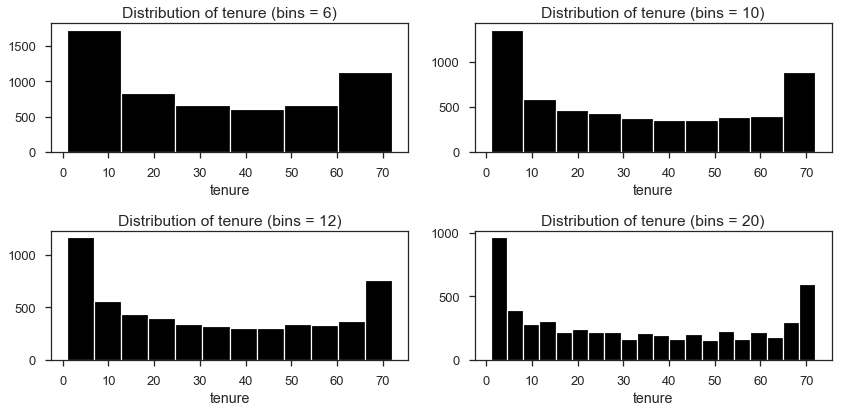

```python
for i, bins in enumerate([6, 10, 12, 20]):
    plot_position = 220+i+1
    plt.subplot(plot_position)
    plot_histogram(data_df=X_train,
                   feature_label='tenure',
                   nb_bins=bins)

plt.tight_layout()
```

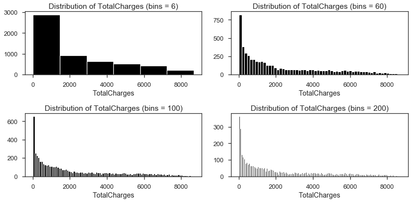

```python
for i, bins in enumerate([6, 60, 100, 200]):
    plot_position = 220+i+1
    plt.subplot(plot_position)

    plot_histogram(data_df=X_train,
                   feature_label='TotalCharges',
                   nb_bins=bins)

plt.tight_layout()
```

### CDF's solve this problem by taking key decisions away from the analyst

$$F(x) = \dfrac{\text{# samples} \leq x }{n} $$

Here is a little function that puts together the scaffolding required.

```python
def plot_cdf(data_df, feature_label):

    x = np.sort(data_df[feature_label])
    y = np.linspace(0, 1, len(x), endpoint=False)

    plt.plot(x, y, color='black')

    for q in [0.25, 0.5, 0.75]:
        plt.axvline(x=np.quantile(x, q),
                    alpha=0.8,
                    linewidth=1.2)

        plt.axhline(y=q,
                    alpha=0.8,
                    linewidth=1.2)

    plt.xlabel(feature_label)
    plt.ylabel('F(x)')
    plt.title('CDF of ' + feature_label)
```

### Let's now plot skewed and non-skewed cumulative distributions

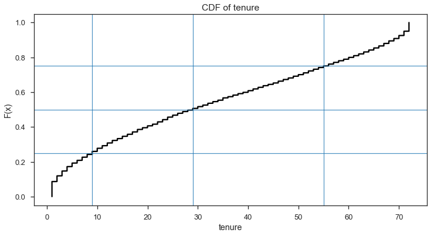

```python
# Non-skewed distribution

plot_cdf(data_df=X_train, feature_label='tenure')
```

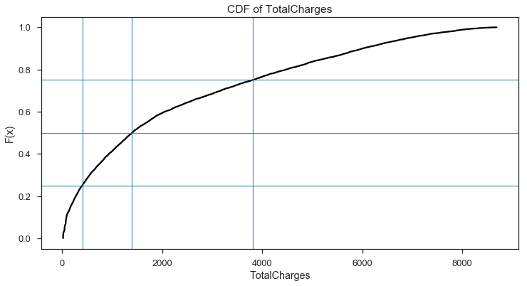

```python
# Skewed distribution

plot_cdf(data_df=X_train, feature_label='TotalCharges')
```

### We can turbo charge the CDF by overlaying a normal distribution

Here is a helper function that superimposes a normal CDF on the data CDF

```python
def plot_cdf_and_normal(data_df, feature_label):

    x = np.sort(data_df[feature_label])

    y = np.linspace(0, 1, len(x), endpoint=False)
    y_norm = ss.norm.cdf(x, np.mean(x), np.std(x))

    plt.plot(x, y, label='data')
    plt.plot(x, y_norm, label='normal distribution')

    plt.xlabel(feature_label)
    plt.legend()
```

### Lets plot the skewed cumulative distribution... again

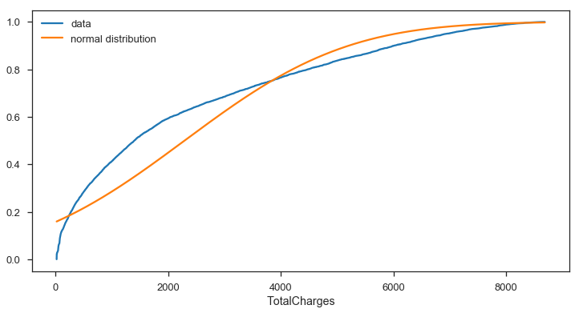

```python
plot_cdf_and_normal(data_df=X_train,
                    feature_label='TotalCharges')
```

### What to do when the features have a skewed distribution?

Call the superstars Yeo - Johnson

$$ y_{i}^{(\lambda)} = \begin{cases} ((y_i+1)^{\lambda} - 1)/\lambda, &\lambda \neq 0, y_i \geq 0 \\ log(y_i+1), &\lambda = 0, y_i \geq 0 \\ -((-y_i+1)^{2-\lambda} - 1)/(2-\lambda), &\lambda \neq 2, y_i < 0 \\ -log(-y_i+1), &\lambda = 2, y_i < 0 \end{cases} $$

```python
def _yeo_johnson_optimize(self, x):
        """Find and return optimal lambda parameter of the Yeo-Johnson
        transform by MLE, for observed data x.
        Like for Box-Cox, MLE is done via the brent optimizer.
        """

        def _neg_log_likelihood(lmbda):
            """Return the negative log likelihood of the observed data x as a
            function of lambda."""
            x_trans = self._yeo_johnson_transform(x, lmbda)
            n_samples = x.shape[0]

            # Estimated mean and variance of the normal distribution
            est_mean = x_trans.sum() / n_samples
            est_var = np.power(x_trans - est_mean, 2).sum() / n_samples

            loglike = -n_samples / 2 * np.log(est_var)
            loglike += (lmbda - 1) * (np.sign(x) * np.log(np.abs(x) + 1)).sum()

            return -loglike

        # the computation of lambda is influenced by NaNs so we need to
        # get rid of them
        x = x[~np.isnan(x)]
        # choosing bracket -2, 2 like for boxcox
        return optimize.brent(_neg_log_likelihood, brack=(-2, 2))
```

```python
# Apply Yeo - Johnson transformation using the PowerTransformer class in scikit

yj_pt = PowerTransformer(method='yeo-johnson')

X_train['TotalCharges_YJ'] = yj_pt.fit_transform(X_train['TotalCharges'].values.reshape(-1,1))
```

Lets see how things work out...

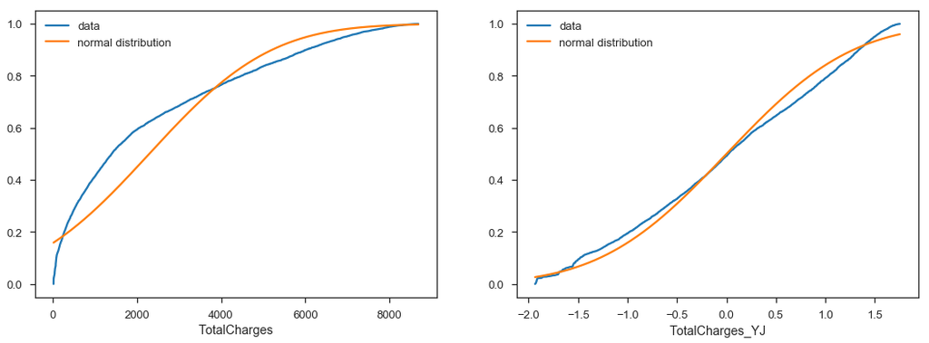

```python
plt.figure(figsize=(18, 6))

plt.subplot(121)
plot_cdf_and_normal(data_df=X_train, feature_label='TotalCharges')


plt.subplot(122)
plot_cdf_and_normal(data_df=X_train, feature_label='TotalCharges_YJ')
```

# Problem 2

[figure not shown]

*'The most important aspect of a statistical analysis is not what you do with the data, it’s what data you use.'* - Andrew Gelman (several times)

First step is to see how deep the rabbit hole is...

```python
def compute_missing_value_counts(data_df):

    counts = data_df.isnull().sum().sort_values(ascending=False)

    return counts[counts != 0]
```

```python
def compute_missing_value_perc(data_df):

    counts = data_df.isnull().sum().sort_values(ascending=False)

    non_zero_counts = counts[counts != 0]

    n_samples = data_df.shape[0]

    return non_zero_counts * 100/n_samples
```

```python
def cols_with_missings(data_df):

    return [col for col in data_df.columns if data_df[col].isnull().any()]
```

Always ask the data source - how did you capture missing values?

```python
churn_raw_df = pd.read_excel('data/WA_Fn-UseC_-Telco-Customer-Churn.xlsx',
                             na_values=' ')
```

```python
compute_missing_value_counts(churn_raw_df)
```

```
TotalCharges    11
dtype: int64
```

```python
compute_missing_value_perc(churn_raw_df)
```

```
TotalCharges    0.156183
dtype: float64
```

```python
cols_with_missings(churn_raw_df)
```

```
['TotalCharges']
```

Lets make the problem a bit more complicated

```python
properties_raw_df = pd.read_csv('data/big/properties_2016.csv')
```

```python
cols_with_missings(properties_raw_df)[0:5] # show only first five in the list
```

```
['airconditioningtypeid',
 'architecturalstyletypeid',
 'basementsqft',
 'bathroomcnt',
 'bedroomcnt']
```

```python
compute_missing_value_perc(properties_raw_df)[0:5] # show 5 worst offenders
```

```
storytypeid                 99.945599
basementsqft                99.945465
yardbuildingsqft26          99.911330
fireplaceflag               99.827048
architecturalstyletypeid    99.796966
dtype: float64
```

Snippet from the `heatmap` function in the `missingno` package

Create and mask the correlation matrix. Call the heatmap from seaborn.

```
corr_mat = df.isnull().corr()

if labels:
    sns.heatmap(corr_mat, mask=mask, cmap=cmap, ax=ax0, cbar=False,
                annot=True, annot_kws={'size': fontsize - 2})
else:
    sns.heatmap(corr_mat, mask=mask, cmap=cmap, ax=ax0, cbar=False)
```

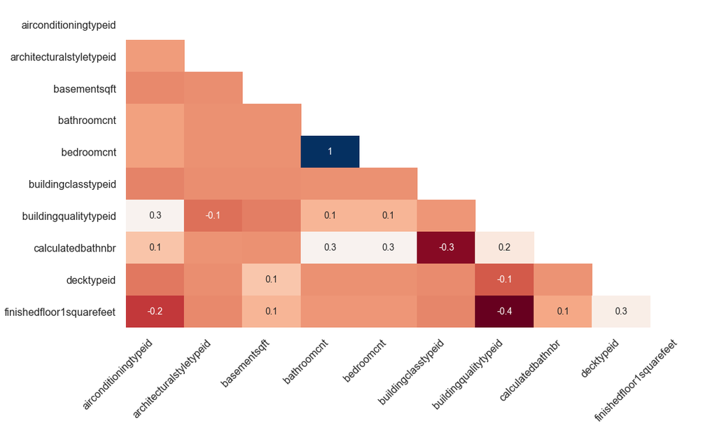

```python
first_ten_missing_columns = cols_with_missings(properties_raw_df)[0:10]

missingno.heatmap(properties_raw_df[first_ten_missing_columns], figsize=(16,9))
```

## What to do with missing data?

Three common strategies

- Drop if okay
- Impute if not okay
- Add flag variable for missing values

### Add flag variable when missing

```python
def add_variable_for_missings(data_df):

    df = data_df.copy()

    for col in df.columns:
        df[col+'_missing'] = df[col].isnull()

    return df
```

```python
properties_missing_cols_df = add_variable_for_missings(properties_raw_df)
```

```python
properties_raw_df.columns[-10:-1]
```

```
Index(['numberofstories', 'fireplaceflag', 'structuretaxvaluedollarcnt',
       'taxvaluedollarcnt', 'assessmentyear', 'landtaxvaluedollarcnt',
       'taxamount', 'taxdelinquencyflag', 'taxdelinquencyyear'],
      dtype='object')
```

```python
cols_with_missings(properties_raw_df)[-10:-1]
```

```
['numberofstories',
 'fireplaceflag',
 'structuretaxvaluedollarcnt',
 'taxvaluedollarcnt',
 'assessmentyear',
 'landtaxvaluedollarcnt',
 'taxamount',
 'taxdelinquencyflag',
 'taxdelinquencyyear']
```

```python
properties_missing_cols_df.columns[-10:-1]
```

```
Index(['numberofstories_missing', 'fireplaceflag_missing',
       'structuretaxvaluedollarcnt_missing', 'taxvaluedollarcnt_missing',
       'assessmentyear_missing', 'landtaxvaluedollarcnt_missing',
       'taxamount_missing', 'taxdelinquencyflag_missing',
       'taxdelinquencyyear_missing'],
      dtype='object')
```

# Problem 3

[figure not shown]

## Correlations can be helpful in sense checking models

### (here we are concerned with correlation between features and target; not collinearity)

Here is a function that computes the correlation between the target and features

```python
def compute_correlations(X_train_df, y_train_df, label_col_str):
    '''
    Compute correlations between all features, select the column corresponding
    to the label, sort values in descending order and drop the entry for the
    label (correlation with itself)

    '''
    data_df = pd.concat([X_train, y_train_df], axis=1)

    correlations_with_target = data_df.corr()[label_col_str].sort_values(ascending=False)[1:]

    corr_df = correlations_with_target.to_frame()

    corr_df.index.name = 'feature'
    corr_df.reset_index(inplace=True)

    return corr_df
```

```python
def plot_correlations(correlation_df, feature_str, label_str):

    g = sns.PairGrid(correlation_df, x_vars=label_str, y_vars=feature_str,
                     size=6, aspect=1.1)

    g.map(sns.stripplot, palette="viridis",
          size=6, orient='h', linewidth=1, edgecolor="white")

    plt.axvline(x=0, color='gray', alpha=0.8, linewidth=1.2)
    plt.axvline(x=.2, color='red', alpha=0.8, linewidth=1.2)
    plt.axvline(x=-.2, color='red', alpha=0.8, linewidth=1.2)
```

Lets run these through some data...

```python
bank_raw_df = pd.read_csv('data/bank-full.csv', delimiter=';')

bank_features = bank_raw_df.drop(columns=['y'])
bank_features_dummified = pd.get_dummies(bank_features, dummy_na=False)

bank_labels = bank_raw_df['y']
```

```python
X_train, X_test, y_train, y_test = train_test_split(bank_features_dummified,
                                                    bank_labels,
                                                    test_size=0.2,
                                                    random_state=20130810)

y_train_df = pd.DataFrame(y_train.apply(lambda x: int(x == 'yes')),
                          columns=['y'])
```

```python
corr_df = compute_correlations(X_train, y_train_df, 'y')
```

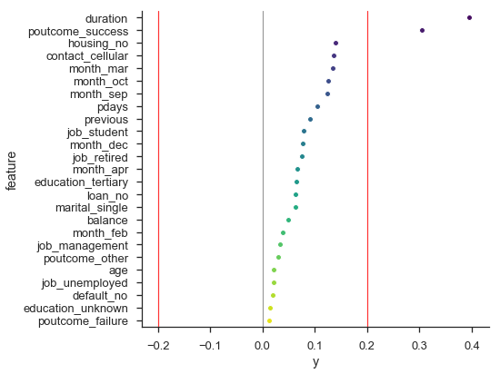

```python
plot_correlations(corr_df.head(25), feature_str='feature', label_str='y')
```

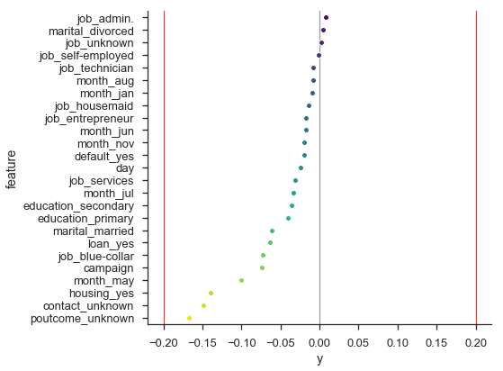

```python
plot_correlations(corr_df.tail(25), feature_str='feature', label_str='y')
```

[figure not shown]